# Backtest: validation on historical data

This notebook contains the simple examples of time series validation using backtest module of ETNA library.

**Table of Contents**

- What is backtest and how it works
- How to run a validation
- Backtest with FoldMask
- Validation visualisation
- Metrics visualisation

```python
import pandas as pd
import matplotlib.pyplot as plt

from etna.datasets.tsdataset import TSDataset
from etna.metrics import MAE
from etna.metrics import MSE
from etna.metrics import SMAPE
from etna.pipeline import Pipeline
from etna.models import ProphetModel
from etna.analysis import plot_backtest
```

### 1. What is backtest and how it works

Backtest is a predictions and validation pipeline build on historical data to make a legitimate retrotest of your model.

**How does it work?**

When constructing a forecast using Models and further evaluating the prediction metrics, we measure the quality at one time interval, designated as test.

Backtest allows you to simulate how the model would work in the past:

- selects a period of time in the past
- builds a model using the selected interval as a training sample
- predicts the value on the test interval and calculates metrics.

The image shows a plot of the backtest pipeline with `n_folds = 3`.

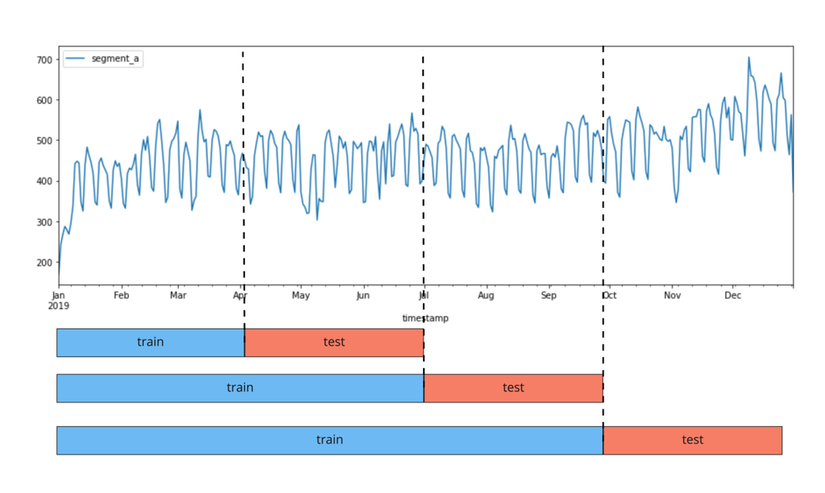

```python
img = plt.imread("./assets/backtest/backtest.jpg")
plt.figure(figsize=(15, 10))
plt.axis("off")
_ = plt.imshow(img)
```

Below we will call a fold the train + test pair, for which training and forecasting is performed.

```python
df = pd.read_csv("./data/example_dataset.csv")
df["timestamp"] = pd.to_datetime(df["timestamp"])
df = df.loc[df.segment == "segment_a"]
df.head()
```

|  | timestamp | segment | target |
| --- | --- | --- | --- |
| 0 | 2019-01-01 | segment_a | 170 |
| 1 | 2019-01-02 | segment_a | 243 |
| 2 | 2019-01-03 | segment_a | 267 |
| 3 | 2019-01-04 | segment_a | 287 |
| 4 | 2019-01-05 | segment_a | 279 |

Our library works with the special data structure TSDataset. So, before starting the EDA, we need to convert the classical DataFrame to TSDataset.

```python
df = TSDataset.to_dataset(df)
ts = TSDataset(df, freq="D")
```

```python
ts
```

| segment feature timestamp | segment_a target |
| --- | --- |
| 2019-01-01 | 170 |
| 2019-01-02 | 243 |
| 2019-01-03 | 267 |
| 2019-01-04 | 287 |
| 2019-01-05 | 279 |
| ... | ... |
| 2019-11-26 | 591 |
| 2019-11-27 | 606 |
| 2019-11-28 | 555 |
| 2019-11-29 | 581 |
| 2019-11-30 | 502 |

334 rows × 1 columns

#### Let's get a look on series

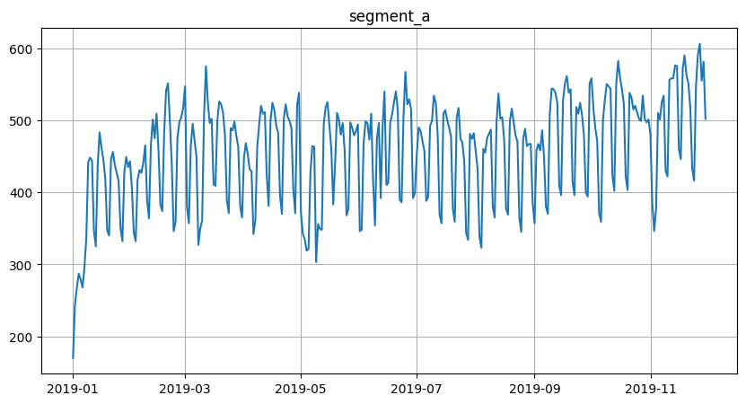

```python
ts.plot(segments=["segment_a"])
```

### 2. How to run a validation

For an easy start let's create a Prophet model

```python
horizon = 31  # Set the horizon for predictions
model = ProphetModel()  # Create a model
transforms = []  # A list of transforms -  we will not use any of them
```

### `Pipeline`

Now let's create an instance of `Pipeline`.

```python
pipeline = Pipeline(model=model, transforms=transforms, horizon=horizon)
```

We are going to run `backtest` method for it. As a result, three dataframes will be returned:

- dataframe with metrics for each fold and each segment,
- dataframe with predictions,
- dataframe with information about folds.

```python
metrics_df, forecast_df, fold_info_df = pipeline.backtest(ts=ts, metrics=[MAE(), MSE(), SMAPE()])
```

[output not shown]

```python
metrics_df.head()
```

|  | segment | MAE | MSE | SMAPE | fold_number |
| --- | --- | --- | --- | --- | --- |
| 0 | segment_a | 18.745404 | 588.926463 | 4.347391 | 0 |
| 0 | segment_a | 21.024841 | 673.118098 | 4.842393 | 1 |
| 0 | segment_a | 29.971619 | 1304.106076 | 6.272921 | 2 |
| 0 | segment_a | 35.971121 | 1997.238578 | 7.420776 | 3 |
| 0 | segment_a | 32.003503 | 1871.567526 | 6.470869 | 4 |

```python
# NEW 2023-11
forecast_df.head(32)
```

| segment feature timestamp | segment_a fold_number | segment_a target |
| --- | --- | --- |
| 2019-06-29 | 0 | 395.000182 |
| 2019-06-30 | 0 | 385.909298 |
| 2019-07-01 | 0 | 492.913153 |
| 2019-07-02 | 0 | 509.357902 |
| 2019-07-03 | 0 | 497.506677 |
| 2019-07-04 | 0 | 488.318069 |
| 2019-07-05 | 0 | 477.565861 |
| 2019-07-06 | 0 | 395.978195 |
| 2019-07-07 | 0 | 386.887311 |
| 2019-07-08 | 0 | 493.891166 |
| 2019-07-09 | 0 | 510.335915 |
| 2019-07-10 | 0 | 498.484690 |
| 2019-07-11 | 0 | 489.296082 |
| 2019-07-12 | 0 | 478.543874 |
| 2019-07-13 | 0 | 396.956209 |
| 2019-07-14 | 0 | 387.865325 |
| 2019-07-15 | 0 | 494.869179 |
| 2019-07-16 | 0 | 511.313929 |
| 2019-07-17 | 0 | 499.462704 |
| 2019-07-18 | 0 | 490.274096 |
| 2019-07-19 | 0 | 479.521888 |
| 2019-07-20 | 0 | 397.934222 |
| 2019-07-21 | 0 | 388.843338 |
| 2019-07-22 | 0 | 495.847193 |
| 2019-07-23 | 0 | 512.291942 |
| 2019-07-24 | 0 | 500.440717 |
| 2019-07-25 | 0 | 491.252109 |
| 2019-07-26 | 0 | 480.499901 |
| 2019-07-27 | 0 | 398.912236 |
| 2019-07-28 | 0 | 389.821352 |
| 2019-07-29 | 0 | 496.825206 |
| 2019-07-30 | 1 | 506.601239 |

```python
fold_info_df.head()
```

|  | train_start_time | train_end_time | test_start_time | test_end_time | fold_number |
| --- | --- | --- | --- | --- | --- |
| 0 | 2019-01-01 | 2019-06-28 | 2019-06-29 | 2019-07-29 | 0 |
| 1 | 2019-01-01 | 2019-07-29 | 2019-07-30 | 2019-08-29 | 1 |
| 2 | 2019-01-01 | 2019-08-29 | 2019-08-30 | 2019-09-29 | 2 |
| 3 | 2019-01-01 | 2019-09-29 | 2019-09-30 | 2019-10-30 | 3 |
| 4 | 2019-01-01 | 2019-10-30 | 2019-10-31 | 2019-11-30 | 4 |

```python
# NEW 2023-11
# Train + Test:
# 6M + 1M
# 7M + 1M
# ...
```

You can additionally get the metrics averaged over folds:

```python
metrics_df, forecast_df, fold_info_df = pipeline.backtest(
    ts=ts, metrics=[MAE(), MSE(), SMAPE()], aggregate_metrics=True
)
```

[output not shown]

```python
metrics_df.head()
```

|  | segment | MAE | MSE | SMAPE |
| --- | --- | --- | --- | --- |
| 0 | segment_a | 27.543298 | 1286.991348 | 5.87087 |

```python
forecast_df.head()
```

| segment feature timestamp | segment_a fold_number | segment_a target |
| --- | --- | --- |
| 2019-06-29 | 0 | 395.000182 |
| 2019-06-30 | 0 | 385.909298 |
| 2019-07-01 | 0 | 492.913153 |
| 2019-07-02 | 0 | 509.357902 |
| 2019-07-03 | 0 | 497.506677 |

```python
fold_info_df.head()
```

|  | train_start_time | train_end_time | test_start_time | test_end_time | fold_number |
| --- | --- | --- | --- | --- | --- |
| 0 | 2019-01-01 | 2019-06-28 | 2019-06-29 | 2019-07-29 | 0 |
| 1 | 2019-01-01 | 2019-07-29 | 2019-07-30 | 2019-08-29 | 1 |
| 2 | 2019-01-01 | 2019-08-29 | 2019-08-30 | 2019-09-29 | 2 |
| 3 | 2019-01-01 | 2019-09-29 | 2019-09-30 | 2019-10-30 | 3 |
| 4 | 2019-01-01 | 2019-10-30 | 2019-10-31 | 2019-11-30 | 4 |

```python
# NEW 2023-11
#raise KeyboardInterrupt
```

### 3. Backtest with fold masks

You can use your backtest strategies using `FoldMask`. In order to make a `FoldMask`, you need to specify `first_train_timestamp`, `last_train_timestamp`, `target_timestamps`. Then you need to pass a list of masks as the `n_folds` parameter to the `pipeline.backtest`.

Consider 3 strategies similar to `SlidingWindowSplitter`, `ExpandingWindowSplitter` and `SingleWindowSplitter` from `sktime`.

#### `ExpandingWindowSplitter`

For this backtest strategy you can use our backtest with `mode="expand"`.

```python
# metrics_df, _, _ = pipeline.backtest(ts=ts, metrics=[MAE(), MSE(), SMAPE()], n_folds=3, mode="expand")
metrics_df, _, fold_info_df = pipeline.backtest(ts=ts, metrics=[MAE(), MSE(), SMAPE()], n_folds=3, mode="expand")
```

[output not shown]

```python
metrics_df
```

|  | segment | MAE | MSE | SMAPE | fold_number |
| --- | --- | --- | --- | --- | --- |
| 0 | segment_a | 29.971619 | 1304.106076 | 6.272921 | 0 |
| 0 | segment_a | 35.971121 | 1997.238578 | 7.420776 | 1 |
| 0 | segment_a | 32.003503 | 1871.567526 | 6.470869 | 2 |

```python
fold_info_df
```

|  | train_start_time | train_end_time | test_start_time | test_end_time | fold_number |
| --- | --- | --- | --- | --- | --- |
| 0 | 2019-01-01 | 2019-08-29 | 2019-08-30 | 2019-09-29 | 0 |
| 1 | 2019-01-01 | 2019-09-29 | 2019-09-30 | 2019-10-30 | 1 |
| 2 | 2019-01-01 | 2019-10-30 | 2019-10-31 | 2019-11-30 | 2 |

#### `SingleWindowSplitter`

For this backtest strategy you can use our backtest with parameter `n_folds=1` or if you need specific window from your dataset you can create a mask with `FoldMask`.

```python
from etna.pipeline import FoldMask
import numpy as np
```

```python
# 1 Without mask

#metrics_df, _, _ = pipeline.backtest(ts=ts, metrics=[MAE(), MSE(), SMAPE()], n_folds=1)
metrics_df, _, fold_info_df = pipeline.backtest(ts=ts, metrics=[MAE(), MSE(), SMAPE()], n_folds=1)
metrics_df
```

[output not shown]

|  | segment | MAE | MSE | SMAPE | fold_number |
| --- | --- | --- | --- | --- | --- |
| 0 | segment_a | 32.003503 | 1871.567526 | 6.470869 | 0 |

```python
fold_info_df
```

|  | train_start_time | train_end_time | test_start_time | test_end_time | fold_number |
| --- | --- | --- | --- | --- | --- |
| 0 | 2019-01-01 | 2019-10-30 | 2019-10-31 | 2019-11-30 | 0 |

```python
# 2 With specific mask
window_size = 85
first_train_timestamp = ts.index.min() + np.timedelta64(100, "D")
last_train_timestamp = first_train_timestamp + np.timedelta64(window_size, "D")
target_timestamps = pd.date_range(start=last_train_timestamp + np.timedelta64(1, "D"), periods=horizon)
mask = FoldMask(
    first_train_timestamp=first_train_timestamp,
    last_train_timestamp=last_train_timestamp,
    target_timestamps=target_timestamps,
)
```

```python
## 1 Without mask
# NEW 2023-11: With mask

#metrics_df, _, _ = pipeline.backtest(ts=ts, metrics=[MAE(), MSE(), SMAPE()], n_folds=[mask])
metrics_df, _, fold_info_df = pipeline.backtest(ts=ts, metrics=[MAE(), MSE(), SMAPE()], n_folds=[mask])
metrics_df
```

[output not shown]

|  | segment | MAE | MSE | SMAPE | fold_number |
| --- | --- | --- | --- | --- | --- |
| 0 | segment_a | 39.782294 | 2191.914481 | 9.056343 | 0 |

```python
fold_info_df
```

|  | train_start_time | train_end_time | test_start_time | test_end_time | fold_number |
| --- | --- | --- | --- | --- | --- |
| 0 | 2019-04-11 | 2019-07-05 | 2019-07-06 | 2019-08-05 | 0 |

#### `SlidingWindowSplitter`

To implement this backtest strategy you need to create a list of fold masks with `FoldMask`.

```python
n_folds = 3
```

```python
def sliding_window_masks(window_size, n_folds):
    masks = []
    for n in range(n_folds):
        first_train_timestamp = ts.index.min() + np.timedelta64(100, "D") + np.timedelta64(n, "D")
        last_train_timestamp = first_train_timestamp + np.timedelta64(window_size, "D")
        target_timestamps = pd.date_range(start=last_train_timestamp + np.timedelta64(1, "D"), periods=horizon)
        mask = FoldMask(
            first_train_timestamp=first_train_timestamp,
            last_train_timestamp=last_train_timestamp,
            target_timestamps=target_timestamps,
        )
        masks.append(mask)
    return masks
```

```python
masks = sliding_window_masks(window_size=window_size, n_folds=n_folds)
#metrics_df, _, _ = pipeline.backtest(ts=ts, metrics=[MAE(), MSE(), SMAPE()], n_folds=masks)
metrics_df, _, fold_info_df = pipeline.backtest(ts=ts, metrics=[MAE(), MSE(), SMAPE()], n_folds=masks)
```

[output not shown]

```python
metrics_df
```

|  | segment | MAE | MSE | SMAPE | fold_number |
| --- | --- | --- | --- | --- | --- |
| 0 | segment_a | 39.782294 | 2191.914481 | 9.056343 | 0 |
| 0 | segment_a | 40.293273 | 2287.327210 | 9.108208 | 1 |
| 0 | segment_a | 39.861472 | 2192.540804 | 9.010115 | 2 |

```python
# NEW 2023-11
fold_info_df
```

|  | train_start_time | train_end_time | test_start_time | test_end_time | fold_number |
| --- | --- | --- | --- | --- | --- |
| 0 | 2019-04-11 | 2019-07-05 | 2019-07-06 | 2019-08-05 | 0 |
| 1 | 2019-04-12 | 2019-07-06 | 2019-07-07 | 2019-08-06 | 1 |
| 2 | 2019-04-13 | 2019-07-07 | 2019-07-08 | 2019-08-07 | 2 |

### 4. Validation visualisation

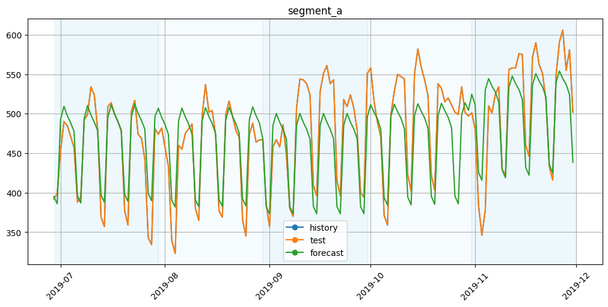

```python
plot_backtest(forecast_df, ts)
```

To visualize the train part, you can specify the `history_len` parameter.

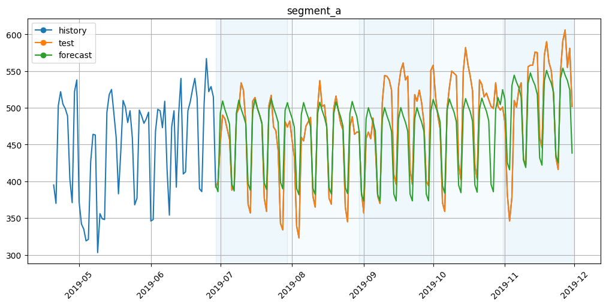

```python
plot_backtest(forecast_df, ts, history_len=70)
```

### 5. Metrics visualization

In this section we will analyze the backtest results from the different point of views.

```python
from etna.analysis import (
    metric_per_segment_distribution_plot,
    plot_residuals,
    plot_metric_per_segment,
    prediction_actual_scatter_plot,
)
```

```python
df = pd.read_csv("./data/example_dataset.csv")
df["timestamp"] = pd.to_datetime(df["timestamp"])
df = TSDataset.to_dataset(df)
ts_all = TSDataset(df, freq="D")
```

```python
metrics_df, forecast_df, fold_info_df = pipeline.backtest(ts=ts_all, metrics=[MAE(), MSE(), SMAPE()])
```

[output not shown]

Let's look at the distribution of the SMAPE metric by folds. You can set `type_plot` as `box`, `violin` or `hist`.

```python
metrics_df
```

|  | segment | MAE | MSE | SMAPE | fold_number |
| --- | --- | --- | --- | --- | --- |
| 0 | segment_a | 18.745404 | 588.926463 | 4.347391 | 0 |
| 0 | segment_a | 21.024841 | 673.118098 | 4.842393 | 1 |
| 0 | segment_a | 29.971619 | 1304.106076 | 6.272921 | 2 |
| 0 | segment_a | 35.971121 | 1997.238578 | 7.420776 | 3 |
| 0 | segment_a | 32.003503 | 1871.567526 | 6.470869 | 4 |
| 1 | segment_b | 14.263371 | 276.358544 | 6.445990 | 0 |
| 1 | segment_b | 10.138933 | 162.564202 | 4.719849 | 1 |
| 1 | segment_b | 8.545600 | 94.532805 | 3.965995 | 2 |
| 1 | segment_b | 8.991734 | 137.976028 | 3.937129 | 3 |
| 1 | segment_b | 13.988861 | 324.884058 | 5.868157 | 4 |
| 2 | segment_c | 30.285960 | 13687.878960 | 11.371755 | 0 |
| 2 | segment_c | 22.116894 | 575.305927 | 15.852056 | 1 |
| 2 | segment_c | 8.998033 | 151.343283 | 6.755015 | 2 |
| 2 | segment_c | 26.511729 | 866.146602 | 18.425543 | 3 |
| 2 | segment_c | 24.435941 | 675.791400 | 14.931914 | 4 |
| 3 | segment_d | 48.989573 | 3864.217332 | 7.971027 | 0 |
| 3 | segment_d | 55.608545 | 3974.852222 | 8.789501 | 1 |
| 3 | segment_d | 81.223644 | 9648.702704 | 10.832489 | 2 |
| 3 | segment_d | 60.533846 | 6136.418452 | 7.210430 | 3 |
| 3 | segment_d | 73.366012 | 8203.742275 | 9.226469 | 4 |

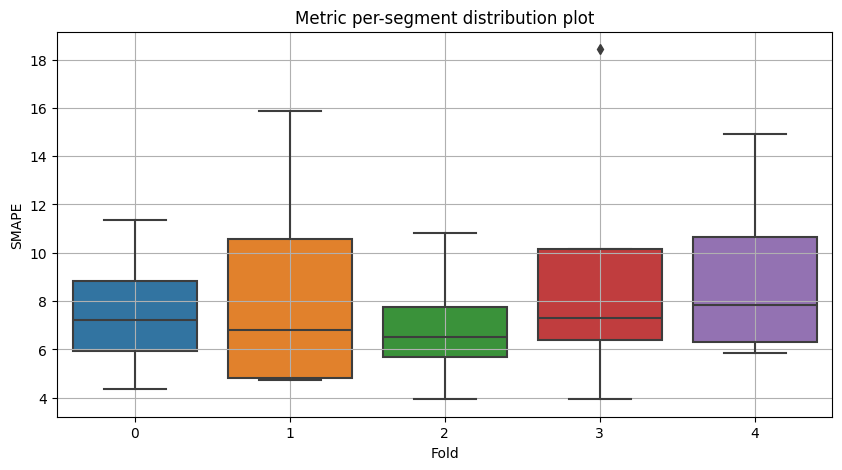

```python
metric_per_segment_distribution_plot(metrics_df=metrics_df, metric_name="SMAPE", plot_type="box")
```

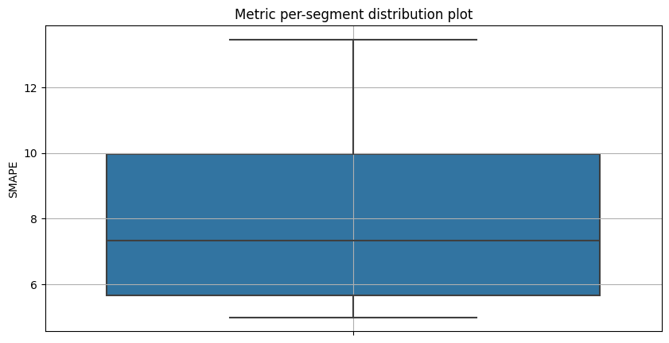

```python
# NEW 2023-11
# Check "mean" mode
metric_per_segment_distribution_plot(metrics_df=metrics_df, metric_name="SMAPE", plot_type="box",
                                    per_fold_aggregation_mode="mean")
```

Let's look at the SMAPE metric by segments

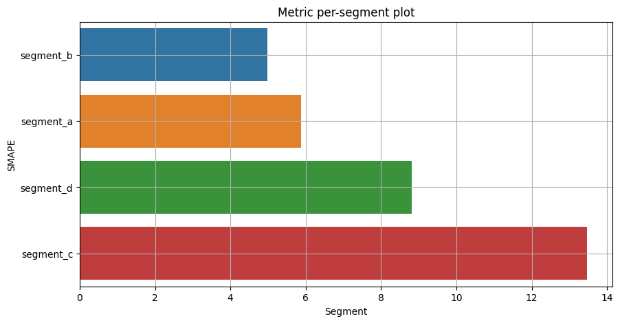

```python
plot_metric_per_segment(metrics_df=metrics_df, metric_name="SMAPE", ascending=True)
```

Now let's look at the residuals of the model predictions from the backtest. Analysis of the residuals can help establish a dependency in the data that our model was not able to find. This way we can add features or improve the model or make sure that there is no dependency in the residuals. Also, you can visualize the residuals not only by timestamp but by any feature.

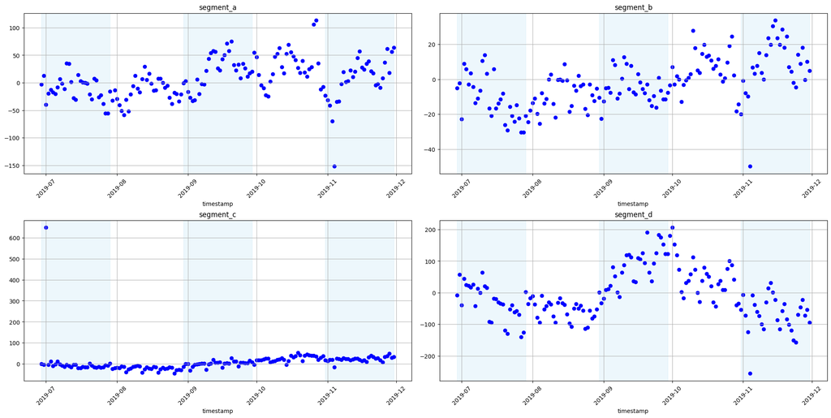

```python
plot_residuals(forecast_df=forecast_df, ts=ts_all)
```

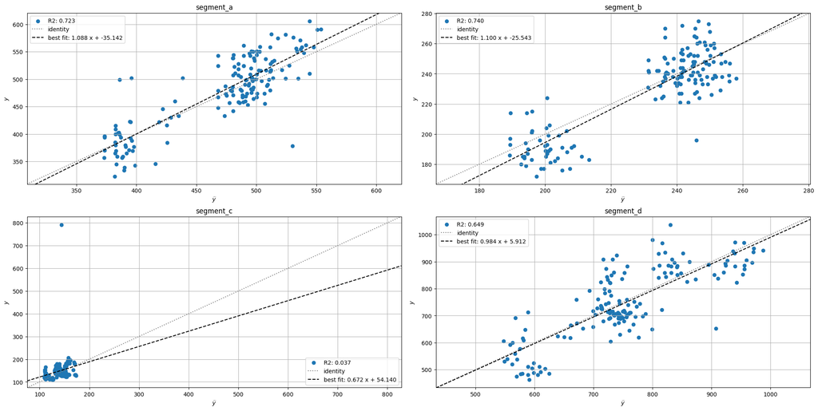

```python
prediction_actual_scatter_plot(forecast_df=forecast_df, ts=ts_all)
```

That's all for this notebook. More features you can find in our documentation!